# Travel Package Purchase Prediction - Amogh Antarkar

### EDA

### Univariate analysis

```python
# function to plot a boxplot and a histogram along the same scale.


def histogram_boxplot(data, feature, figsize=(12, 7), kde=False, bins=None):
    """
    Boxplot and histogram combined

    data: dataframe
    feature: dataframe column
    figsize: size of figure (default (12,7))
    kde: whether to show the density curve (default False)
    bins: number of bins for histogram (default None)
    """
    f2, (ax_box2, ax_hist2) = plt.subplots(
        nrows=2,  # Number of rows of the subplot grid= 2
        sharex=True,  # x-axis will be shared among all subplots
        gridspec_kw={"height_ratios": (0.25, 0.75)},
        figsize=figsize,
    )  # creating the 2 subplots
    sns.boxplot(
        data=data, x=feature, ax=ax_box2, showmeans=True, color="violet"
    )  # boxplot will be created and a star will indicate the mean value of the column
    sns.histplot(
        data=data, x=feature, kde=kde, ax=ax_hist2, bins=bins, palette="winter"
    ) if bins else sns.histplot(
        data=data, x=feature, kde=kde, ax=ax_hist2
    )  # For histogram
    ax_hist2.axvline(
        data[feature].mean(), color="green", linestyle="--"
    )  # Add mean to the histogram
    ax_hist2.axvline(
        data[feature].median(), color="black", linestyle="-"
    )  # Add median to the histogram
```

### Observations on Age

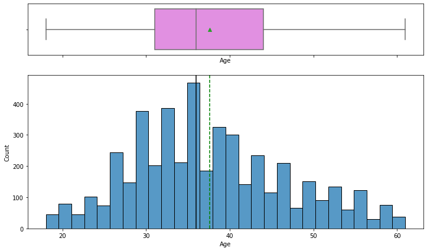

```python
histogram_boxplot(data,'Age')
```

- Age is looking normally distributed, with a hint of right skew.

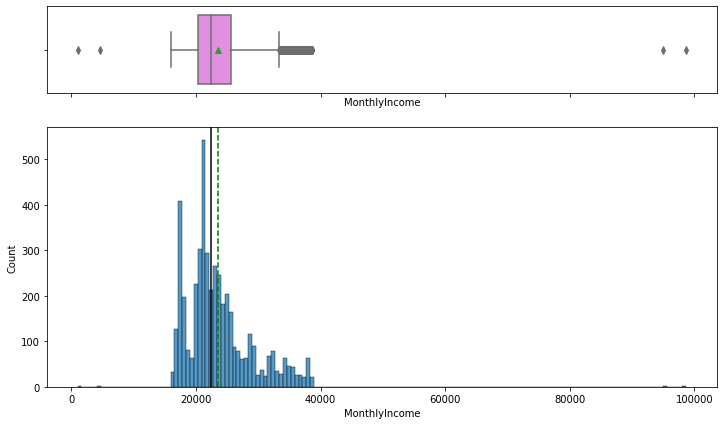

```python
histogram_boxplot(data,'MonthlyIncome')
```

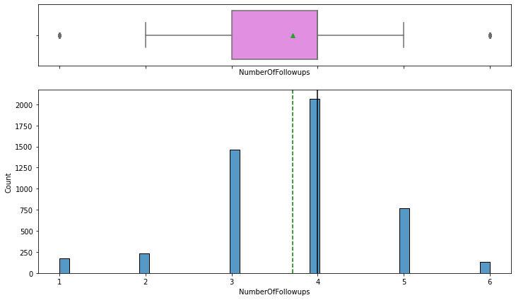

```python
histogram_boxplot(data,'NumberOfFollowups')
```

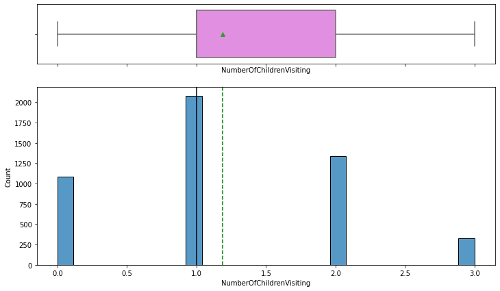

```python
histogram_boxplot(data,'NumberOfChildrenVisiting')
```

[figure not shown]

```python
histogram_boxplot(data,'TotalWorkingYears')
```

```python
# function to create labeled barplots


def labeled_barplot(data, feature, perc=False, n=None):
    """
    Barplot with percentage at the top

    data: dataframe
    feature: dataframe column
    perc: whether to display percentages instead of count (default is False)
    n: displays the top n category levels (default is None, i.e., display all levels)
    """

    total = len(data[feature])  # length of the column
    count = data[feature].nunique()
    if n is None:
        plt.figure(figsize=(count + 1, 5))
    else:
        plt.figure(figsize=(n + 1, 5))

    plt.xticks(rotation=90, fontsize=15)
    ax = sns.countplot(
        data=data,
        x=feature,
        palette="Paired",
        order=data[feature].value_counts().index[:n].sort_values(),
    )

    for p in ax.patches:
        if perc == True:
            label = "{:.1f}%".format(
                100 * p.get_height() / total
            )  # percentage of each class of the category
        else:
            label = p.get_height()  # count of each level of the category

        x = p.get_x() + p.get_width() / 2  # width of the plot
        y = p.get_height()  # height of the plot

        ax.annotate(
            label,
            (x, y),
            ha="center",
            va="center",
            size=12,
            xytext=(0, 5),
            textcoords="offset points",
        )  # annotate the percentage

    plt.show()  # show the plot
```

```
Index(['ProdTaken', 'Age', 'TypeofContact', 'CityTier', 'DurationOfPitch',
       'Occupation', 'Gender', 'NumberOfPersonVisiting', 'NumberOfFollowups',
       'ProductPitched', 'PreferredPropertyStar', 'MaritalStatus',
       'NumberOfTrips', 'Passport', 'PitchSatisfactionScore', 'OwnCar',
       'NumberOfChildrenVisiting', 'Designation', 'MonthlyIncome'],
      dtype='object')
```

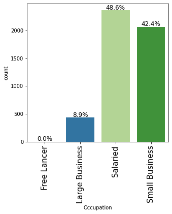

```python
print(data.columns)
labeled_barplot(data, "Occupation", perc=True)
```

### Observations on CityTier

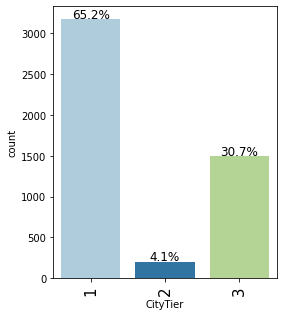

```python
labeled_barplot(data, "CityTier", perc=True)
```

- most people belong to 1st tier city

### Observations on NumberOfTrips

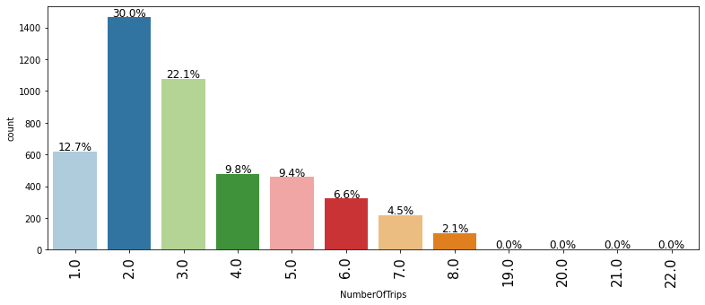

```python
labeled_barplot(data, "NumberOfTrips", perc=True)
```

- most people have 1-3 trips travel

### Observations on NumberOfChildrenVisiting

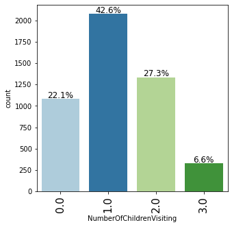

```python
labeled_barplot(data, "NumberOfChildrenVisiting", perc=True)
```

### Observations on ProdTaken,TypeofContact

[output not shown]

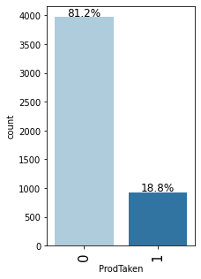

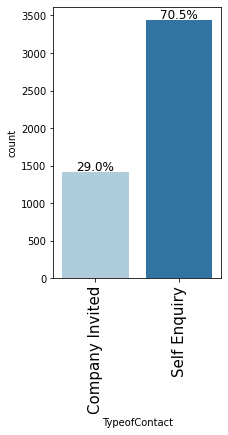

```python
print(data.columns)
labeled_barplot(data, "ProdTaken", perc=True)
labeled_barplot(data, "TypeofContact", perc=True)
```

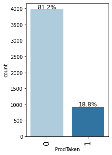

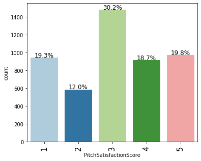

```python
labeled_barplot(data, "ProdTaken", perc=True)
labeled_barplot(data, "PitchSatisfactionScore", perc=True)
```

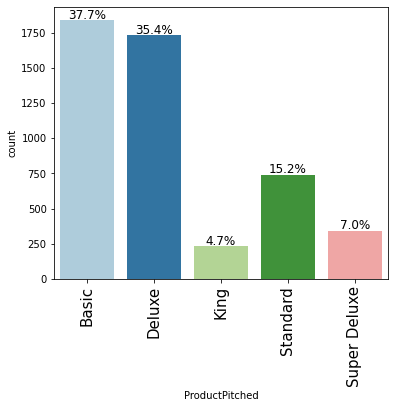

```python
labeled_barplot(data, "ProductPitched", perc=True)
```

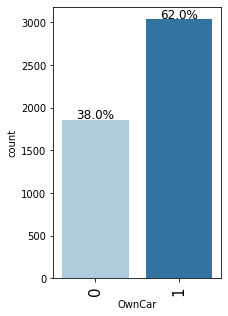

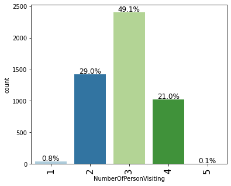

```python
labeled_barplot(data, "OwnCar", perc=True)
labeled_barplot(data, "NumberOfPersonVisiting", perc=True)
```

## Bivariate Analysis

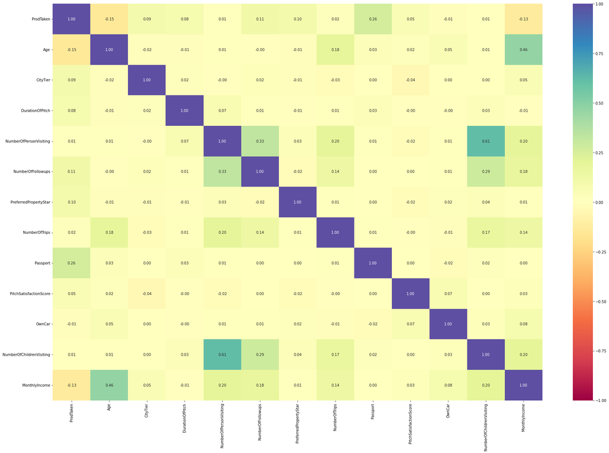

```python
plt.figure(figsize=(30,20))
sns.heatmap(data.corr(),annot=True,vmin=-1,vmax=1,fmt='.2f',cmap="Spectral")
plt.show()
```

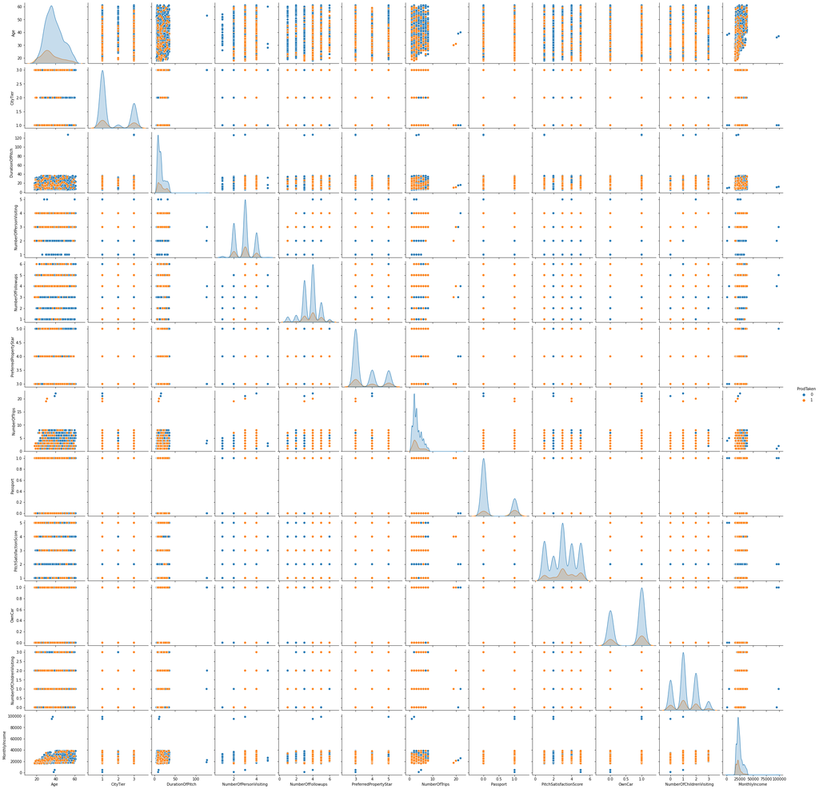

```python
sns.pairplot(data,hue='ProdTaken')
plt.show()
```

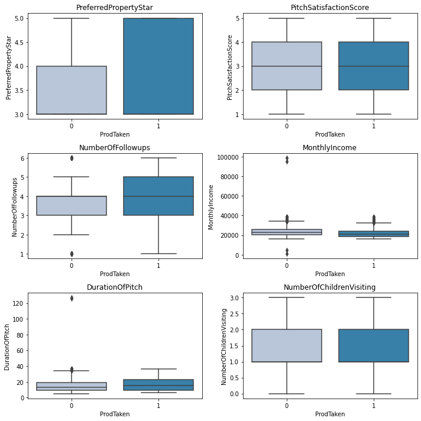

```python
cols = data[['PreferredPropertyStar', 'PitchSatisfactionScore','NumberOfFollowups','MonthlyIncome','DurationOfPitch','NumberOfChildrenVisiting']].columns.tolist()
plt.figure(figsize=(10,10))

for i, variable in enumerate(cols):
                     plt.subplot(3,2,i+1)
                     sns.boxplot(data["ProdTaken"],data[variable],palette="PuBu")
                     plt.tight_layout()
                     plt.title(variable)
plt.show()
```

```python
# function to plot stacked bar chart


def stacked_barplot(data, predictor, target):
    """
    Print the category counts and plot a stacked bar chart

    data: dataframe
    predictor: independent variable
    target: target variable
    """
    count = data[predictor].nunique()
    sorter = data[target].value_counts().index[-1]
    tab1 = pd.crosstab(data[predictor], data[target], margins=True).sort_values(
        by=sorter, ascending=False
    )
    print(tab1)
    print("-" * 120)
    tab = pd.crosstab(data[predictor], data[target], normalize="index").sort_values(
        by=sorter, ascending=False
    )
    tab.plot(kind="bar", stacked=True, figsize=(count + 1, 5))
    plt.legend(
        loc="lower left",
        frameon=False,
    )
    plt.legend(loc="upper left", bbox_to_anchor=(1, 1))
    plt.show()
```

[output not shown]

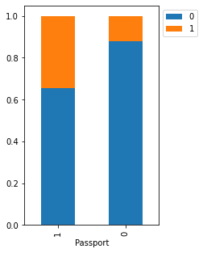

```python
stacked_barplot(data, "Passport", "ProdTaken")
```

[output not shown]

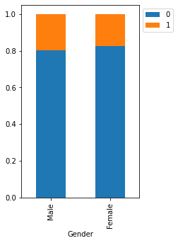

[output not shown]

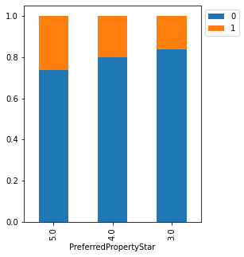

```python
stacked_barplot(data,"Gender","ProdTaken")
stacked_barplot(data,"PreferredPropertyStar","ProdTaken")
```

[output not shown]

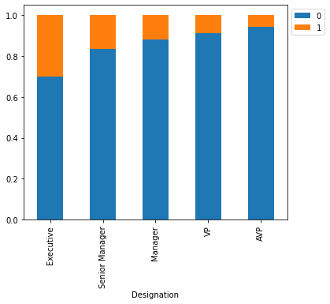

```python
stacked_barplot(data,"Designation","ProdTaken")
```

[output not shown]

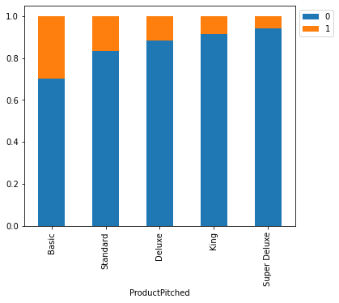

```python
# data.columns
stacked_barplot(data,"ProductPitched","ProdTaken")
```

[output not shown]

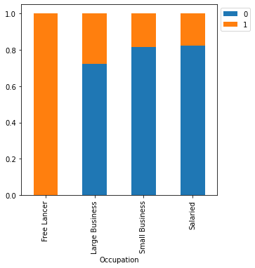

[output not shown]

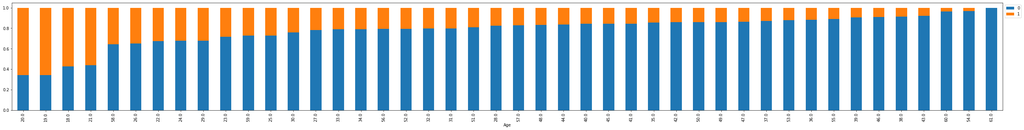

```python
stacked_barplot(data,"Occupation","ProdTaken")
stacked_barplot(data,"Age","ProdTaken")
```

### Summary of EDA

**Data Description:**

**Data Cleaning:**

- CustomerID variable is not useful for predictive modeling.
- Gender has issues 'Female'

**Observations from EDA:**

## Model Building - Approach

1. Data preparation
2. Partition the data into train and test set.
3. Build model on the train data.
4. Tune the model if required.
5. Test the data on test set.
- We try to maximize the F1 score by ensuring good recall since we want to save money and be targeted and not just focus on precision

## Split Data

```python
data.columns
```

```
Index(['ProdTaken', 'Age', 'TypeofContact', 'CityTier', 'DurationOfPitch',
       'Occupation', 'Gender', 'NumberOfPersonVisiting', 'NumberOfFollowups',
       'ProductPitched', 'PreferredPropertyStar', 'MaritalStatus',
       'NumberOfTrips', 'Passport', 'PitchSatisfactionScore', 'OwnCar',
       'NumberOfChildrenVisiting', 'Designation', 'MonthlyIncome'],
      dtype='object')
```

```python
data['ProdTaken'].value_counts()
```

```
0    3946
1     917
Name: ProdTaken, dtype: int64
```

```python
X = data.drop(['ProdTaken'],axis=1)
X = pd.get_dummies(X,drop_first=True)
y = data['ProdTaken'] #.apply(lambda x : 1 if x=='Yes' else 0)
```

```python
# Splitting data into training and test set:
X_train, X_test, y_train, y_test =train_test_split(X, y, test_size=0.3, random_state=1,stratify=y)
print(X_train.shape, X_test.shape)
```

```
(3404, 29) (1459, 29)
```

```python
y.value_counts(1)
```

```
0    0.811433
1    0.188567
Name: ProdTaken, dtype: float64
```

```python
y_test.value_counts(1)
```

```
0    0.811515
1    0.188485
Name: ProdTaken, dtype: float64
```

## Model evaluation criterion

### Which case is more important?

- Predicting that person will and should be targeted need good f1 score with better precision and decent recall since we want to save on costs and be focussed in targetting.

```python
def confusion_matrix_sklearn(model, predictors, target):
    """
    To plot the confusion_matrix with percentages

    model: classifier
    predictors: independent variables
    target: dependent variable
    """
    y_pred = model.predict(predictors)
    cm = confusion_matrix(target, y_pred)
    labels = np.asarray(
        [
            ["{0:0.0f}".format(item) + "\n{0:.2%}".format(item / cm.flatten().sum())]
            for item in cm.flatten()
        ]
    ).reshape(2, 2)

    plt.figure(figsize=(6, 4))
    sns.heatmap(cm, annot=labels, fmt="")
    plt.ylabel("True label")
    plt.xlabel("Predicted label")
```

```python
# defining a function to compute different metrics to check performance of a classification model built using sklearn
def model_performance_classification_sklearn(model, predictors, target):
    """
    Function to compute different metrics to check classification model performance

    model: classifier
    predictors: independent variables
    target: dependent variable
    """

    # predicting using the independent variables
    pred = model.predict(predictors)

    acc = accuracy_score(target, pred)  # to compute Accuracy
    recall = recall_score(target, pred)  # to compute Recall
    precision = precision_score(target, pred)  # to compute Precision
    f1 = f1_score(target, pred)  # to compute F1-score

    # creating a dataframe of metrics
    df_perf = pd.DataFrame(
        {
            "Accuracy": acc,
            "Recall": recall,
            "Precision": precision,
            "F1": f1,
        },
        index=[0],
    )

    return df_perf
```

## Build Decision Tree Model

```
Training performance
    Accuracy  Recall  Precision   F1
0       1.0     1.0        1.0  1.0
Testing performance
    Accuracy    Recall  Precision        F1
0  0.885538  0.712727   0.690141  0.701252
```

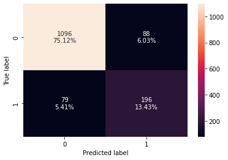

```python
dtree = DecisionTreeClassifier(criterion='gini',random_state=1)
dtree.fit(X_train, y_train)
confusion_matrix_sklearn(dtree, X_test, y_test)
dtree_model_train_perf=model_performance_classification_sklearn(dtree, X_train, y_train)
print("Training performance \n",dtree_model_train_perf)
dtree_model_test_perf=model_performance_classification_sklearn(dtree, X_test, y_test)
print("Testing performance \n",dtree_model_test_perf)
```

```
Training performance
    Accuracy  Recall  Precision   F1
0       1.0     1.0        1.0  1.0
Testing performance
    Accuracy    Recall  Precision        F1
0  0.911583  0.763636   0.766423  0.765027
```

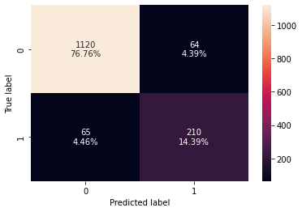

```python
dtree = DecisionTreeClassifier(criterion='gini',class_weight={0:0.18,1:0.82},random_state=1)
dtree.fit(X_train, y_train)
confusion_matrix_sklearn(dtree, X_test, y_test)
dtree_model_train_perf=model_performance_classification_sklearn(dtree, X_train, y_train)
print("Training performance \n",dtree_model_train_perf)
dtree_model_test_perf=model_performance_classification_sklearn(dtree, X_test, y_test)
print("Testing performance \n",dtree_model_test_perf)
```